# Predicting_customer_churn_using_logistic_regression1

"Finall Exercises"

> - Information **DATA**

> https://community.ibm.com/community/user/businessanalytics/blogs/steven-macko/2019/07/11/telco-customer-churn-1113
- 1. Exploratory Data Anlysis(EDA)
  - 1.1 Load The Datset
  - 1.2 Data Description
  - 1.3 Data Cleaning
    - 1.3.1 Missing Value
    - 1.3.2 Duplicated
    - 1.3.3 Outliter
- 2.Dianostics Analytics and Data Visualization
  - 2.1 Gender, Seniority, Partner and Pependends
  - 2.2 Services
  - 2.3 Security_support
  - 2.4 Contract type
  - 2.5 Churn analysis based on paying options
  - 2.6 Churn analysis based on tenure group
  - 2.7 Charges

1 |Exploring The Dataset

```python
import pandas as pd, numpy as np, seaborn as sns, matplotlib.pyplot as plt # Operation and Visualization
import warnings
%matplotlib inline
warnings.filterwarnings("ignore")
pd.set_option('display.max_columns', None)
```

## **1.1 Load The dataset**

```python
df = pd.read_csv('https://raw.githubusercontent.com/ManonYa09/Statistics_with_Python_G6/main/Dataset/4.%20WA_Fn-UseC_-Telco-Customer-Churn.csv')
```

[output not shown]

## **1.2 Basic Data Exploration or Quick Exploration**

```
- df.head() # Displays the first 5 rows of the DataFrame.
- df.shape # show the numbers of rows and columns of dataset
- df.iloc[[ rows], [columns]] # df.iloc[[0, 1], [2, 3]]  # Selects rows 0 and 1, columns 2 and 3
- df.loc[[ rows], [columns]] # df.loc[[0, 1], ['column1', 'column2']]  # Selects rows 0 and 1, columns 'column1' and 'column2'
- df.dtypes # Returns the data types of each column.
- df.info() # Provides a concise summary of the DataFrame, including the number of non-null entries and data types.
- df.describe() # Generates descriptive statistics for numeric columns, such as count, mean, and standard deviation.
```

`Note:` You should apply the function above to better understand our dataset before we proceed to the exercise questions.

1. What types of data are in each column of the dataset?
2. Are there any missing values in the dataset?
3. How many unique values are in the "PaymentMethod" column?
4. Identify any duplicate records in the dataset. How many are there?
5. What is the average monthly charge for customers?

### Customer Details

6. How does the tenure of a customer relate to churn?
7. How many customers have a tenure greater than 50 months?
8. Is there a correlation between monthly charges and total charges? (optional question)
9. What percentage of customers have opted for paperless billing?
10. How does the churn rate vary with different contract types?

## **1.3 Data Cleaning**

```
- df.isnull().sum() # Displays the number of missing (null) values in each column
- df[column].isnull() # Returns a boolean series indicating whether each value in the specified column is missing.
- df.dropna(inplace = True) | dataset = df.dropna() # Removes all rows with missing values. Using inplace=True modifies the DataFrame directly, while assigning to a new variable keeps the original DataFrame unchanged.
- df.duplicated().sum() # Returns the number of duplicate rows in the DataFrame.
```

### Data Cleaning

11. Clean the data by replacing "No internet service" and 'No phone service' with "No" in our Dataset.
12. Are there any outliers in the monthly charges? Use a boxplot to explore.

### **1.3.1 Missing Value**

### **1.3.2 Duplicated**

```python
## df.duplicated().sum()
```

[output not shown]

```python
# df[df.duplicated()]
```

### **1.3.3 Outlier**

```python
df.boxplot()
```

[output not shown]

2 |Diagnostics Analytics with Data Visualization

### Data Visualization

13. Generate a bar chart showing the count of customers by payment method.
14. Use a histogram to show the distribution of tenure among all customers.
15. Create a scatter plot comparing tenure to monthly charges for churned customers.
16. Generate a line plot showing churn trends over different tenures.
17. Use a violin plot to compare the distribution of tenure for churned vs. non-churned customers.
18. Create a pie chart showing the distribution of customers by contract length.
19. Generate a stacked bar chart showing proportions of churn by contract type.

### Filtering and Pivot Tables

22. Filter the dataset to include only customers with a two-year contract.
23. Filter the data to show only customers with "Fiber optic" as their internet service.
24. Filter records to analyze data for customers with dependents.
25. Create a pivot table showing average monthly charges by customer tenure and service.
26. Develop a pivot table summarizing average charges by payment method and paperless billing.

### Business Implications

32. What recommendations can be made to reduce churn based on the analysis?
33. How can the company improve its services to retain more customers?
34. What strategies can be suggested to attract similar profiles of customers who do not churn?
35. How can the findings from this data analysis influence business strategy?
36. What actions can be taken based on the churn analysis to improve business outcomes?

Now, let's understand dataset based on:

#### Gender, Senoirity, Parnter and Dependents

#### Services

#### Security_support

#### Contract type

#### Churn

#### Charges

# **2.1 Gender, Seniority, Partner and Dependends(Customer)**

```python
sns.countplot(x = df['gender'], hue = df['Churn']);
```

[output not shown]

[enumerate(axes.flat)](https://www.tutorialspoint.com/what-does-axes-flat-in-matplotlib-do)

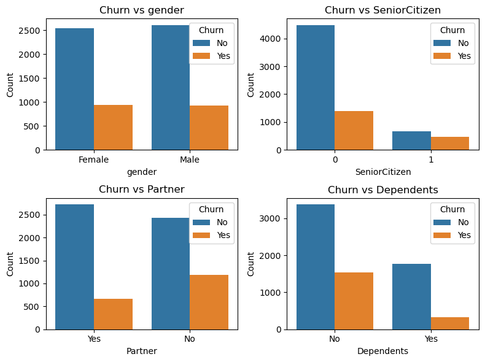

```python
cols = ['gender', 'SeniorCitizen', 'Partner', 'Dependents']
fig, axes = plt.subplots(nrows=2, ncols=2, figsize=(8, 6)) # 2x2 grid of plot

for i, ax in enumerate(axes.flat): # enumerate function is used to loop through each subplot in the grid
    if i < len(cols):
        sns.countplot(data=df, x=cols[i], hue='Churn', ax=ax)
        ax.set_title(f'Churn vs {cols[i]}')
        ax.set_xlabel(cols[i])
        ax.set_ylabel('Count')


plt.tight_layout() # ensuring that each plot is evenly spaced within the figure
plt.show()
```

and finally,

- **customers without dependants churn more** than customers with dependents.

# **2.2 Services**

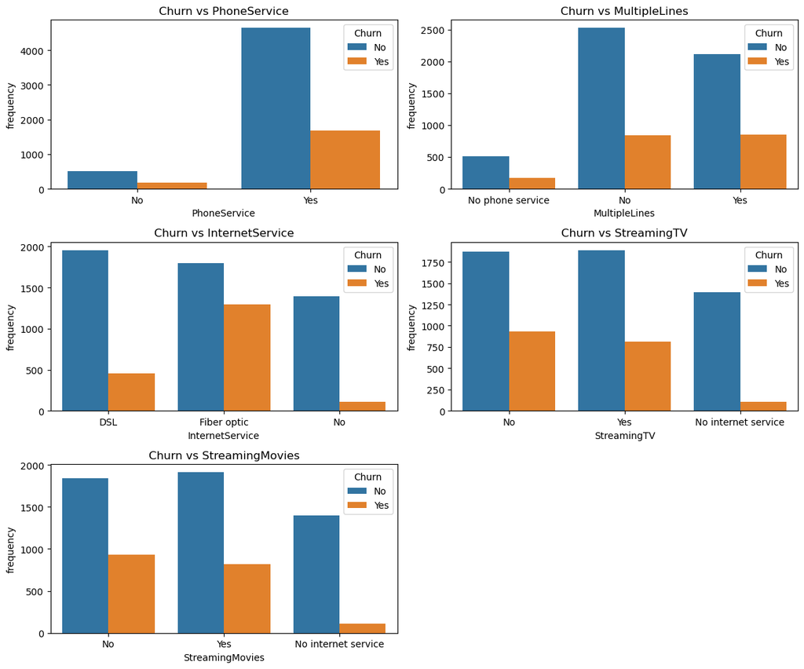

```python
services = df[['Churn', 'PhoneService', 'MultipleLines', 'InternetService','StreamingTV', 'StreamingMovies']]
cols = services.columns[1:]

fig, axes = plt.subplots(nrows=3, ncols=2, figsize=(12,10))

for i, ax in enumerate(axes.flat):

    if i < len(cols):
        sns.countplot(data=services, x=cols[i], hue='Churn', ax=ax)
        ax.set_title(f'Churn vs {cols[i]}')
        ax.set_xlabel(cols[i])
        ax.set_ylabel('frequency')
    else:
        ax.set_visible(False)
plt.tight_layout()
plt.show()
```

```python
df['InternetService'].value_counts()
```

```
InternetService
Fiber optic    3090
DSL            2414
No             1506
Name: count, dtype: int64
```

- Streaming TV, Streaming Movies, Multiple Lines have **no impact** on churn rate.
- Customers who have **fiber optic** tend to **churn** significantly more than ones that have DSL.

Now let's dive deeper into that finding. We need gender, partner status, dependents status and senior status.

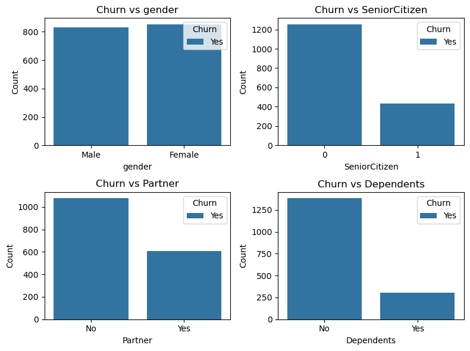

```python
phone_churn = df[(df['PhoneService']=='Yes') & (df['Churn']=='Yes')]

cols = ['gender', 'SeniorCitizen', 'Partner', 'Dependents']
fig, axes = plt.subplots(nrows=2, ncols=2, figsize=(8, 6))

for i, ax in enumerate(axes.flat):
    if i < len(cols):
        sns.countplot(data=phone_churn, x=cols[i], hue='Churn', ax=ax)
        ax.set_title(f'Churn vs {cols[i]}')
        ax.set_xlabel(cols[i])
        ax.set_ylabel('Count')

plt.tight_layout()
plt.show()
```

We can conclude that customers who have churned and use phone service are likely to be **non-seniors, without partners and dependents.** We had got the same conclusion when analyzing the same variables regardless of customers' services.

Now let's investigate the customers who have fiber optic and who have churned.

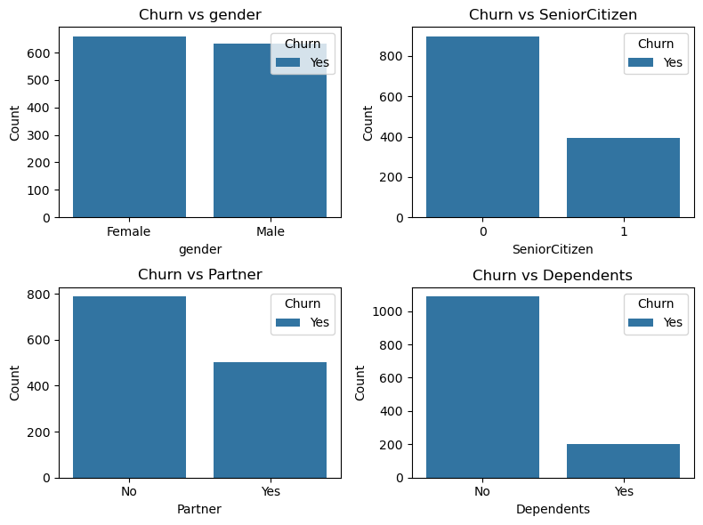

```python
fiber_churn = df[(df['InternetService']=='Fiber optic') & (df['Churn'] == 'Yes')]
fig, axes = plt.subplots(nrows=2, ncols=2, figsize=(8, 6))
cols = ['gender', 'SeniorCitizen', 'Partner', 'Dependents']

for k, ax in enumerate(axes.flat):
    if k < len(cols):
        sns.countplot(data=fiber_churn, x=cols[k], hue='Churn', ax=ax)
        ax.set_title(f'Churn vs {cols[k]}')
        ax.set_xlabel(cols[k])
        ax.set_ylabel('Count')
plt.tight_layout()
plt.show()
```

The same conclusion applies for the customers that have churned and have fiber optic.

# **2.3 Security_support**

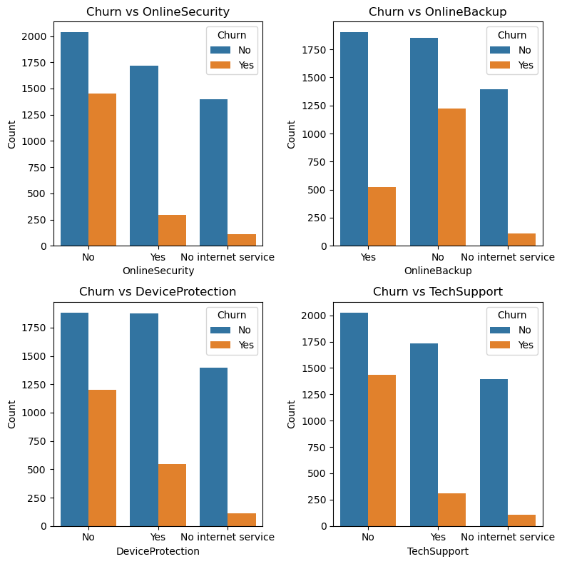

```python
security_support = df[['Churn', 'OnlineSecurity', 'OnlineBackup','DeviceProtection', 'TechSupport']]
cols = security_support.columns[1:]

fig, axes = plt.subplots(nrows=2, ncols=2, figsize=(8,8))

for i, ax in enumerate(axes.flat):
    if i < len(cols):
        sns.countplot(data=security_support, x=cols[i], hue='Churn', ax=ax)
        ax.set_title(f'Churn vs {cols[i]}')
        ax.set_xlabel(cols[i])
        ax.set_ylabel('Count')

plt.tight_layout()
plt.show()
```

# **2.4 Contract type**

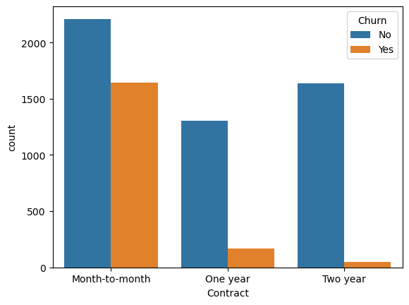

```python
sns.countplot(data=df, x=df['Contract'], hue='Churn')
plt.show()
```

Customers with **Month-to-month contracts** tend to **churn significantly more** often then customers with one year and two year contracts

# **2.5 Churn analysis based on paying options**

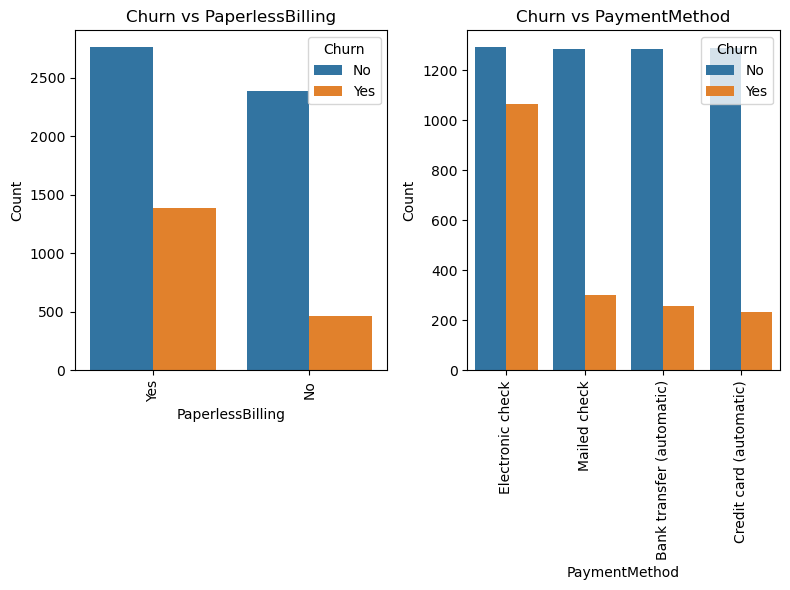

```python
paying_options = df[['Churn', 'PaperlessBilling', 'PaymentMethod']]
cols = paying_options.columns[1:]

fig, axes = plt.subplots(nrows=1, ncols=2, figsize=(8,6))

for i, ax in enumerate(axes.flat):
    if i < len(cols):
        sns.countplot(data=paying_options, x=cols[i], hue='Churn', ax=ax)
        ax.set_title(f'Churn vs {cols[i]}')
        ax.set_xlabel(cols[i])
        ax.set_ylabel('Count')
        ax.set_xticklabels(ax.get_xticklabels(), rotation=90)

plt.tight_layout()
plt.show()
```

# **2.6 Churn analysis based on tenure group**

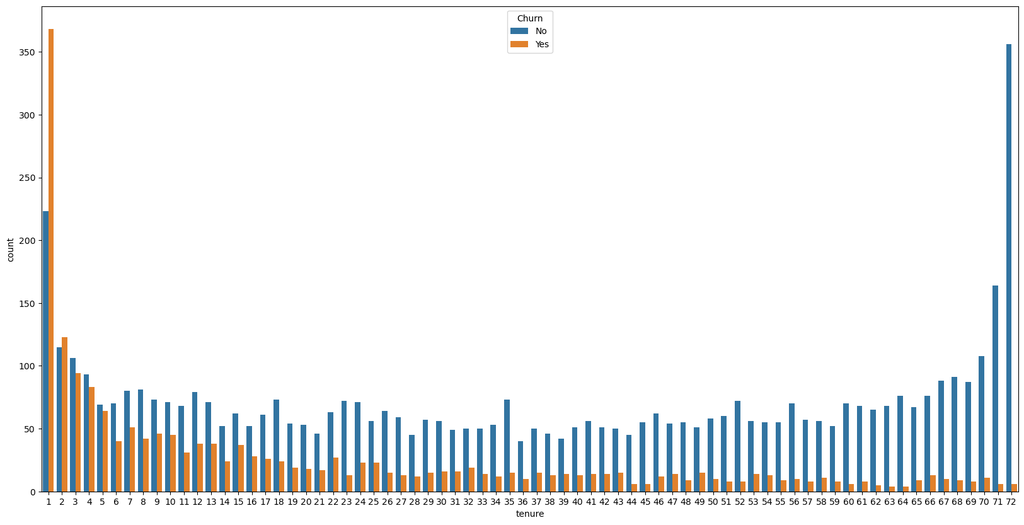

```python
plt.figure(figsize=(20, 10))
sns.countplot(data = df, x = 'tenure', hue = 'Churn')
plt.show()
```

Customers who **spent less than 1 year** using our services tend to **churn substantially more** than the customers of other tenure groups.

As the **tenure increases**, the **churn rate decreases**

# **2.7 Charges**

```python
df[df['TotalCharges']<0]
```

|  | gender | SeniorCitizen | Partner | Dependents | tenure | PhoneService | MultipleLines | InternetService | OnlineSecurity | OnlineBackup | DeviceProtection | TechSupport | StreamingTV | StreamingMovies | Contract | PaperlessBilling | PaymentMethod | MonthlyCharges | TotalCharges | Churn |
| --- | --- | --- | --- | --- | --- | --- | --- | --- | --- | --- | --- | --- | --- | --- | --- | --- | --- | --- | --- | --- |

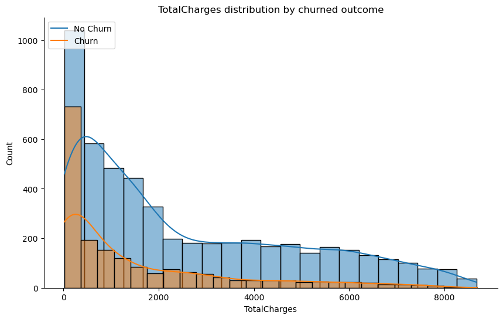

```python
fig, ax = plt.subplots(figsize = (10, 6))
sns.histplot(df['TotalCharges'][df['Churn']=='No'], label='Churn - No', kde=True)
sns.histplot(df['TotalCharges'][df['Churn']=='Yes'], label='Churn - Yes', kde = True)
ax.legend(["No Churn","Churn"],loc='upper left')
ax.set_xlabel('TotalCharges')
ax.set_title('TotalCharges distribution by churned outcome')
sns.despine()
plt.show()
```

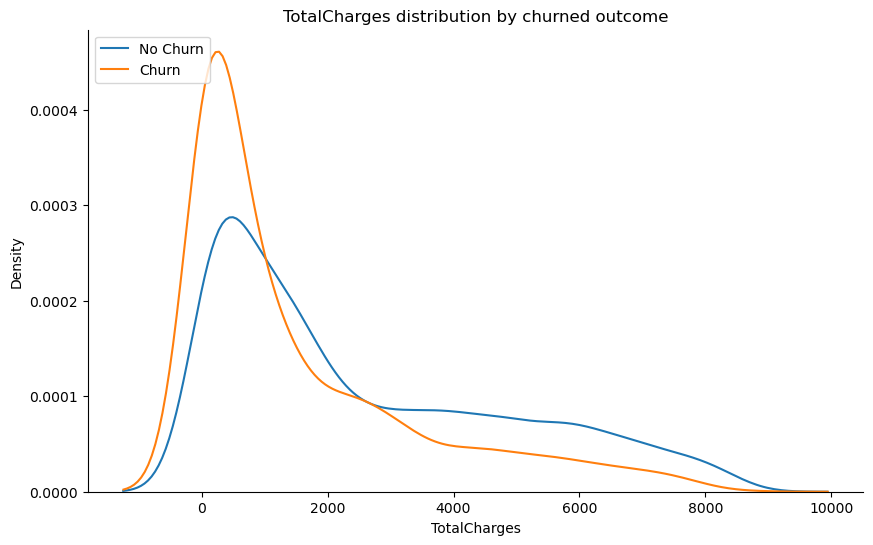

```python
fig, ax = plt.subplots(figsize = (10, 6))
sns.kdeplot(df['TotalCharges'][df['Churn']=='No'], label='Churn - No')
sns.kdeplot(df['TotalCharges'][df['Churn']=='Yes'], label='Churn - Yes')
ax.legend(["No Churn","Churn"],loc='upper left')
ax.set_xlabel('TotalCharges')
ax.set_title('TotalCharges distribution by churned outcome')
sns.despine()
plt.show()
```

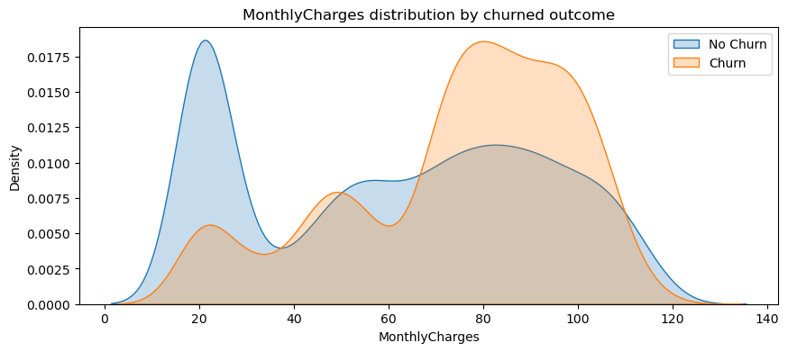

```python
fig, ax = plt.subplots(figsize = (10, 4))
sns.kdeplot(df['MonthlyCharges'][df['Churn']=='No'], label='Churn - No', shade = True)
sns.kdeplot(df['MonthlyCharges'][df['Churn']=='Yes'], label='Churn - Yes', shade = True)
ax.legend(["No Churn","Churn"],loc='upper right')
ax.set_xlabel('MonthlyCharges')
ax.set_title('MonthlyCharges distribution by churned outcome')
plt.show()
```

```python
df.groupby(['Churn'])[['MonthlyCharges','TotalCharges' ]].describe()
```

| Churn | MonthlyCharges count | MonthlyCharges mean | MonthlyCharges std | MonthlyCharges min | MonthlyCharges 25% | MonthlyCharges 50% | MonthlyCharges 75% | MonthlyCharges max | TotalCharges count | TotalCharges mean | TotalCharges std | TotalCharges min | TotalCharges 25% | TotalCharges 50% | TotalCharges 75% | TotalCharges max |
| --- | --- | --- | --- | --- | --- | --- | --- | --- | --- | --- | --- | --- | --- | --- | --- | --- |
| No | 5153.0 | 61.387415 | 31.071570 | 18.25 | 25.1 | 64.55 | 88.55 | 118.75 | 5153.0 | 2560.264118 | 2329.034632 | 18.80 | 581.85 | 1688.9 | 4265.0 | 8672.45 |
| Yes | 1857.0 | 74.604308 | 24.597504 | 18.85 | 56.5 | 79.70 | 94.25 | 118.35 | 1857.0 | 1541.376548 | 1893.151020 | 18.85 | 140.70 | 713.1 | 2345.2 | 8684.80 |

```python
# churn_monthly = pd.Series([df[df['Churn'] == 'Yes']['MonthlyCharges'].mean(),
#                            df[df['Churn'] == 'No']['MonthlyCharges'].mean()],
#                           index=['Churned', 'Non-Churned'])
# churn_total = pd.Series([df[df['Churn'] == 'Yes']['TotalCharges'].mean(),
#                        df[df['Churn'] == 'No']['TotalCharges'].mean()],
#                        index = ['Churned', 'Non-Churned'])
# print(churn_monthly)
# print(churn_total)
```

1. **High Churn rate** is seen for the customers **without dependants, online security, tech support**. Also customers who use **electronic checks** as a payment method, who use **our services less than 1 year** and who have **month-to-month contracts** are likely to churn frequently.